# Introduction to dtGAP

Han-Ming Wu, Chia-Yu Chang, and Chun-houh Chen

2026-02-13

```r
library(dtGAP)
```

# 1 Introduction

Decision trees are prized for their simplicity and interpretability but often fail to reveal underlying data structures. Generalized Association Plots (GAP) excel at illustrating complex associations yet are typically unsupervised. We introduce `dtGAP`, a novel framework that embeds **supervised correlation** and distance measures into GAP for enriched **decision-tree visualization**. `dtGAP` offers confusion matrix maps, decision-tree matrix maps, predicted class membership maps, and evaluation panels. The `dtGAP` package is available on GitHub and CRAN at (https://github.com/hanmingwu1103/dtGAP) and (https://CRAN.R-project.org/package=dtGAP).

# 2 Quick Start

Let’s begin with the penguins dataset! Running the `dtGAP()` function can be as simple as:

```r
penguins <- na.omit(penguins)
dtGAP(
  data_all = penguins, model = "party", show = "all",
  trans_type = "percentize", target_lab = "species",
  simple_metrics = TRUE,
  label_map_colors = c(
    "Adelie" = "#50046d", "Gentoo" = "#fcc47f",
    "Chinstrap" = "#e15b76"
  ),
  show_col_prox = FALSE, show_row_prox = FALSE,
  y_eval_start = 220,
  raw_value_col = colorRampPalette(
    c("#33286b", "#26828e", "#75d054", "#fae51f")
  )(9)
)
```

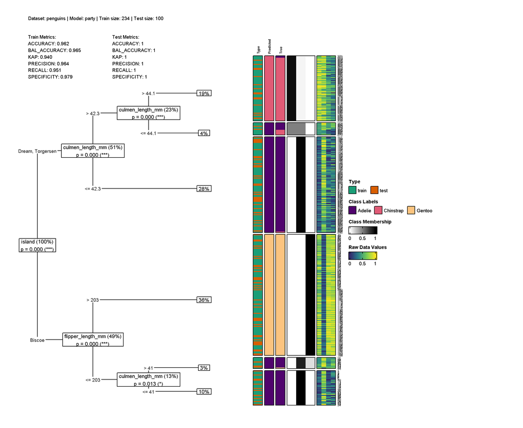

# 3 Selecting Data Subsets and Tree-Based Models

By default `dtGAP` visualizes the entire data, but you can focus on just the training or testing split using the `show` argument, which takes either `'all'`, `'train'` or `'test'`. Similarly, You can choose between two tree models via the `model` argument, which can be either `'rpart'`or `'party'`.

When you choose `model = "rpart"` (classic CART), each node shows its **class-membership probabilities** and display the percentage of samples in each branch.

```r
dtGAP(
  data_all = Psychosis_Disorder, show = "all",
  trans_type = "none", target_lab = "UNIQID", print_eval = FALSE
)
```

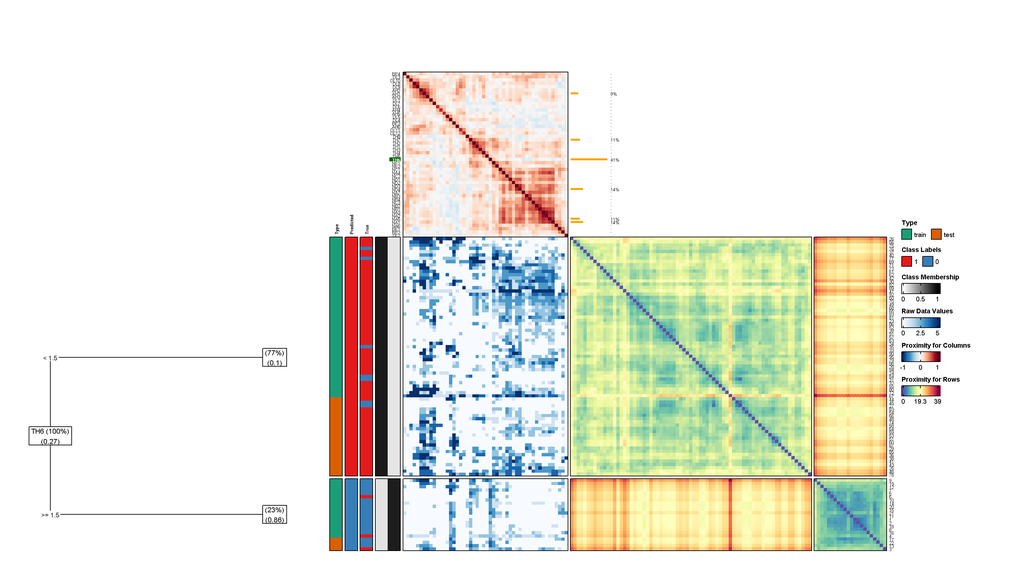

In contrast, with `model = "party"` (conditional inference trees), `dtGAP` will annotate each internal node with its **split-variable p-value** and display the percentage of samples in each branch. Also, you can **custom label mapping and colors.**

```r
dtGAP(
  data_all = Psychosis_Disorder, model = "party", show = "all",
  trans_type = "none", target_lab = "UNIQID", print_eval = FALSE,
  label_map = c("0" = "bipolar", "1" = "schizophrenia"),
  label_map_colors = c("bipolar" = "#50046d", "schizophrenia" = "#fcc47f")
)
```

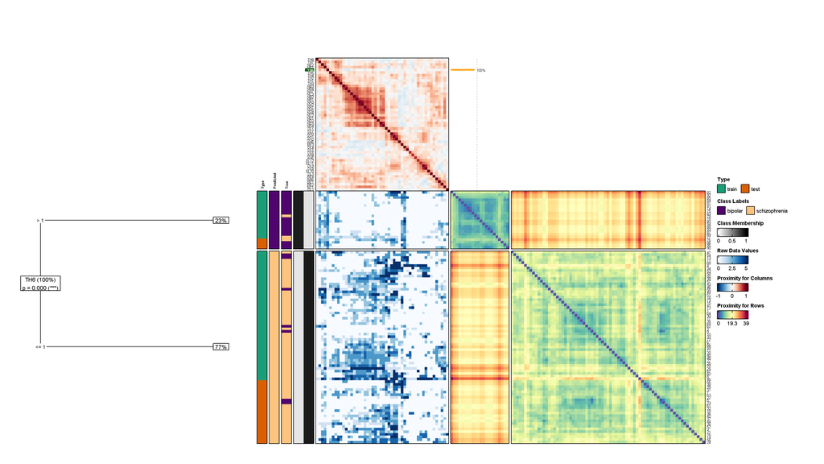

# 4 Computing Row and Column Proximity and Seriation

At the beginning, we choose suitable data transformation via `trans_type` argument, which can be either `'none'`, `'percentize'`, `'normalize'`, and `'scale'`.

Before sorting, we build two proximity measures:

- **Column Proximity** : Calculate a combined conditional correlation matrix weighted by group memberships.
- **Row Proximity** : Initially, sort samples by tree leaf. For each leaf, measure supervised distance—combining within-leaf dispersion and between-leaf separation—using linkage `"CT"` (centroid) , `"SG"` (single), or `"CP"` (complete).

Use any method from `seriation` to reorder rows and columns.

```r
> seriation::list_seriation_methods("dist")
```

```
#>  [1] "ARSA"           "BBURCG"         "BBWRCG"         "Enumerate"
#>  [5] "GSA"            "GW"             "GW_average"     "GW_complete"
#>  [9] "GW_single"      "GW_ward"        "HC"             "HC_average"
#> [13] "HC_complete"    "HC_single"      "HC_ward"        "Identity"
#> [17] "isomap"         "isoMDS"         "MDS"            "MDS_angle"
#> [21] "metaMDS"        "monoMDS"        "OLO"            "OLO_average"
#> [25] "OLO_complete"   "OLO_single"     "OLO_ward"       "QAP_2SUM"
#> [29] "QAP_BAR"        "QAP_Inertia"    "QAP_LS"         "R2E"
#> [33] "Random"         "Reverse"        "Sammon_mapping" "SGD"
#> [37] "Spectral"       "Spectral_norm"  "SPIN_NH"        "SPIN_STS"
#> [41] "TSP"            "VAT"
```

Also, when `show = "all"`, use `sort_by_data_type = TRUE` to preserve the original train/test grouping; set it to `FALSE` if you’d rather intermix samples from both sets when ordering.

*how to measure the quality of sorting?*

Then compute the **cRGAR** —an average of node-specific anti-Robinson scores weighted by each node’s sample fraction—to quantify order quality.

- near 0 means good sorting (ordering the layout closely follows a Robinson structure).
- near 1 indicate bad sorting (many violations).

```r
dtGAP(
  data_all = Psychosis_Disorder, model = "party", show = "all",
  trans_type = "none", target_lab = "UNIQID",
  label_map = c("0" = "bipolar", "1" = "schizophrenia"),
  label_map_colors = c("bipolar" = "#50046d", "schizophrenia" = "#fcc47f"),
  seriate_method = "GW_average", sort_by_data_type = FALSE
)
```

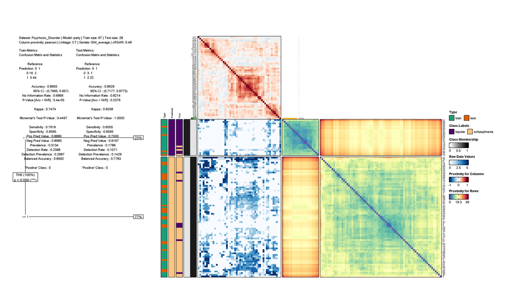

# 5 Data Information and Metrics

When you set `print_eval = TRUE`, `dtGAP` will append an evaluation panel containing two sections:

- **Data Information**
  - Dataset name, model and train/test sample sizes.
  - Column proximity method, linkage, seriation algorithm and cRGAR score.
- **Train/Test Metrics**
  - **Full confusion-matrix report** (default)  
    Uses `caret::confusionMatrix()` to show accuracy, kappa, sensitivity, specificity, etc.
  - **Simple metrics**  
    If you set `simple_metrics = TRUE`, you’ll instead get six key measures from the **yardstick** package:
    - Accuracy
    - Balanced accuracy
    - Kappa
    - Precision
    - Recall
    - Specificity

```r
dtGAP(
  data_all = Psychosis_Disorder, model = "party", show = "all",
  label_map = c("0" = "bipolar", "1" = "schizophrenia"),
  label_map_colors = c("bipolar" = "#50046d", "schizophrenia" = "#fcc47f"),
  trans_type = "none", target_lab = "UNIQID", simple_metrics = TRUE
)
```

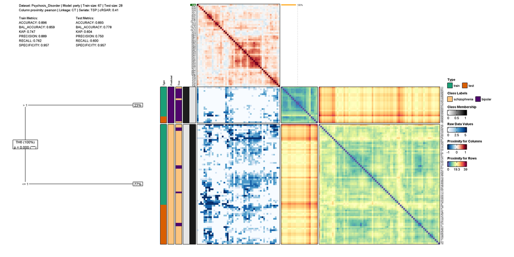

# 6 Train/Test Workflow

```r
dtGAP(
  data_train = train_covid, data_test = test_covid,
  target_lab = "Outcome", show = "train",
  label_map = c("0" = "Survival", "1" = "Death"),
  label_map_colors = c("Survival" = "#50046d", "Death" = "#fcc47f"),
  simple_metrics = TRUE,
  show_col_prox = FALSE, show_row_prox = FALSE,
  y_eval_start = 200,
  raw_value_col = colorRampPalette(
    c("#33286b", "#26828e", "#75d054", "#fae51f")
  )(9)
)
```

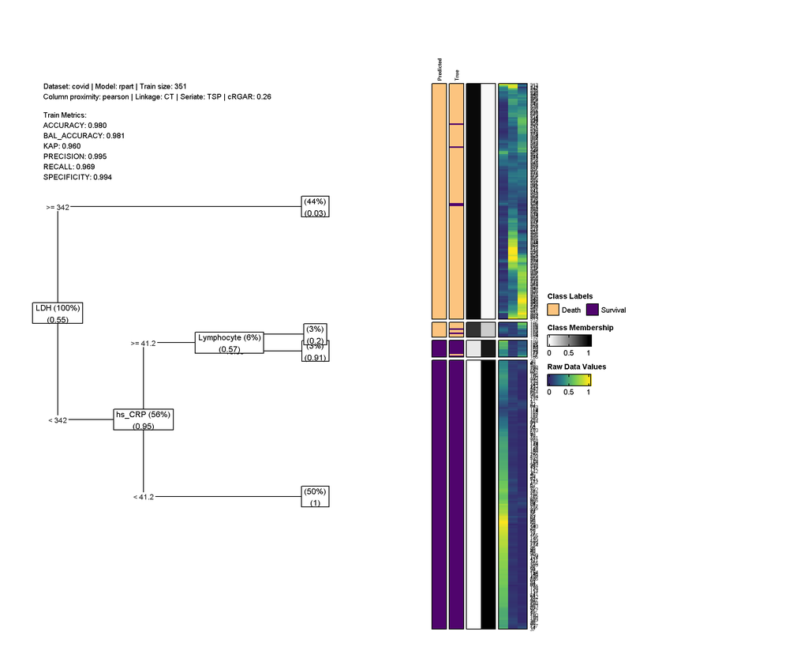

## 6.1 Apply the learned tree on external/holdout/test/validation dataset

- R-squared (RSQ)
- Mean absolute error (MAE)
- Root mean squared error (RMSE)
- Concordance correlation coefficient (CCC).

```r
dtGAP(
  data_train = train_covid, data_test = test_covid,
  target_lab = "Outcome", show = "test",
  label_map = c("0" = "Survival", "1" = "Death"),
  label_map_colors = c("Survival" = "#50046d", "Death" = "#fcc47f"),
  simple_metrics = TRUE,
  show_col_prox = FALSE, show_row_prox = FALSE,
  y_eval_start = 200,
  raw_value_col = colorRampPalette(
    c("#33286b", "#26828e", "#75d054", "#fae51f")
  )(9)
)
```

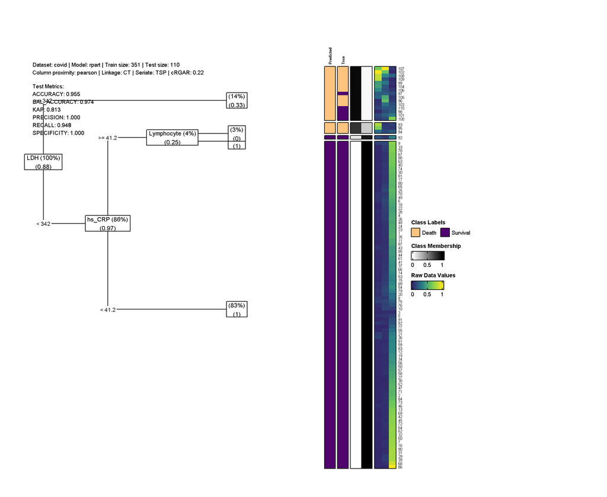

# 7 Regression

Compared with classification, interpreting a regression tree can be challenging. A heatmap, however, can make the structure more transparent by showing how observations cluster within each terminal node. Here’s an example:

```r
dtGAP(
  data_all = galaxy, task = "regression",
  target_lab = "target", show = "all",
  trans_type = "percentize", model = "party",
  simple_metrics = TRUE, y_eval_start = 220,
  raw_value_col = colorRampPalette(
    c("#33286b", "#26828e", "#75d054", "#fae51f")
  )(9)
)
```

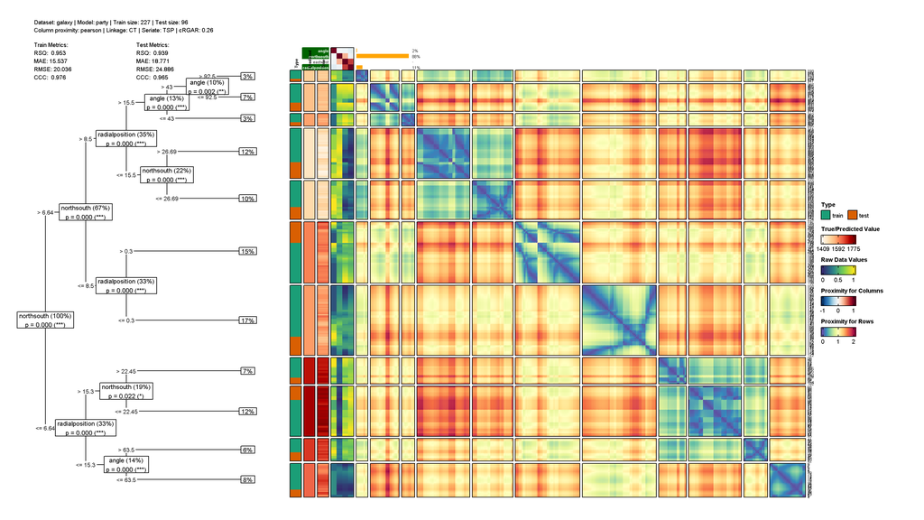

# 8 Customization

- Variable Importance and split-variable Labels panel
  - `col_var_imp` set the bar fill color (e.g. `"orange"`, `"#2c7bb6"`).
  - `var_imp_bar_width` Adjust bar thickness (default `0.8`).
  - `var_imp_fontsize` / `split_var_fontsize` Control the font size (default `5`).
  - `split_var_bg` Background color behind each split-variable name (default `"darkgreen"`).
- **Color**

  Define the `RColorBrewer` palette and number of shades.
  - `Col_Prox_palette` (e.g. `"RdBu"`, `"Viridis"`) and `Col_Prox_n_colors`
  - `Row_Prox_palette` and `Row_Prox_n_colors`
  - `sorted_dat_palette` & `sorted_dat_n_colors`

Uses `display.brewer.all()` to displays all available RColorBrewer palettes.

You can customize the color schemes and font sizes in the visualization to match your preferences.

```r
dtGAP(
  data_all = Psychosis_Disorder, show = "all", trans_type = "none",
  target_lab = "UNIQID", simple_metrics = TRUE, col_var_imp = "blue",
  split_var_bg = "darkblue", Col_Prox_palette = "RdYlGn",
  type_palette = "Set2",
  Row_Prox_palette = "Spectral",
  var_imp_fontsize = 7, split_var_fontsize = 7,
  sorted_dat_palette = "Oranges", sorted_dat_n_colors = 9,
  label_map = c("0" = "bipolar", "1" = "schizophrenia"),
  label_map_colors = c("bipolar" = "#50046d", "schizophrenia" = "#fcc47f")
)
```

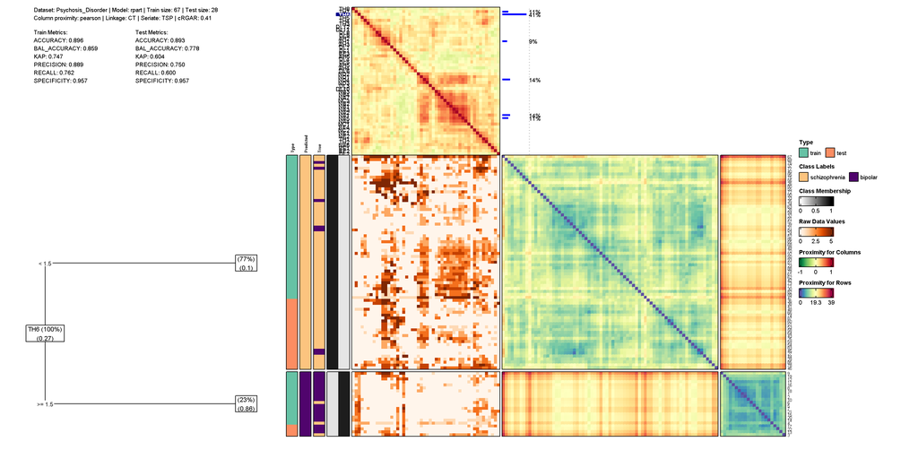

You can also choose whether to display the row or column proximity.

```r
dtGAP(
  data_all = Psychosis_Disorder, model = "party", show = "all",
  trans_type = "none", target_lab = "UNIQID",
  seriate_method = "GW_average",
  label_map = c("0" = "bipolar", "1" = "schizophrenia"),
  label_map_colors = c("bipolar" = "#50046d", "schizophrenia" = "#fcc47f"),
  show_row_prox = FALSE, show_col_prox = FALSE
)
```

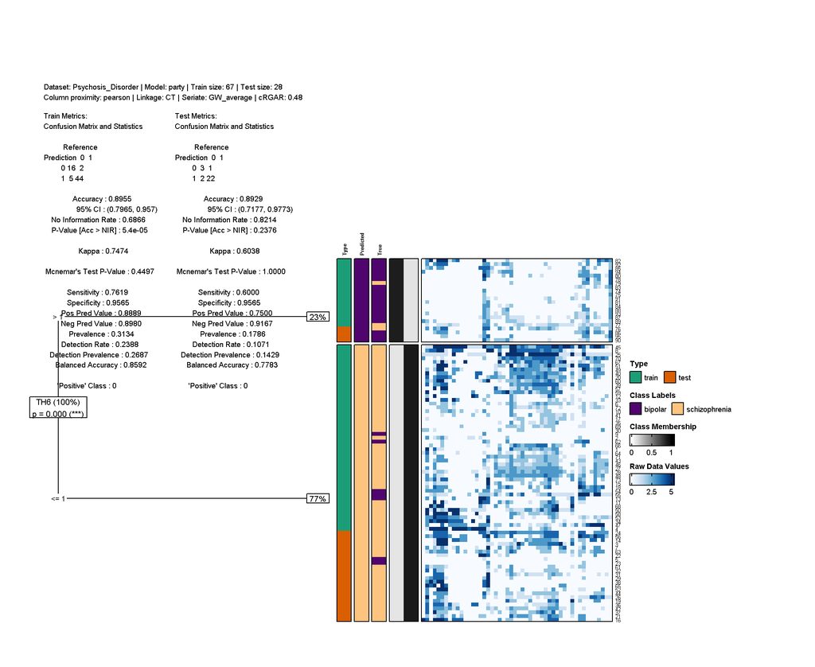

# 9 Smart Node Layout

While extreme tree visualizations may reduce immediate interpretability, they effectively illustrate the structural adaptability of our layout algorithm in the context of increasing tree complexity. The horizontal positioning of tree components is governed by the `tree_p` parameter in `dtGAP()`, which determines the proportion of the overall canvas dedicated to the tree structure. Adjusting `tree_p` helps mitigate issues such as branch overlapping by providing adequate spacing between nodes.

```r
dtGAP(
  data_all = wine_quality_red, target_lab = "target",
  show = "all", model = "party", simple_metrics = TRUE,
  show_col_prox = FALSE, show_row_prox = FALSE,
  y_eval_start = 40,
  raw_value_col = colorRampPalette(
    c("#33286b", "#26828e", "#75d054", "#fae51f")
  )(9),
  show_row_names = FALSE
)
```

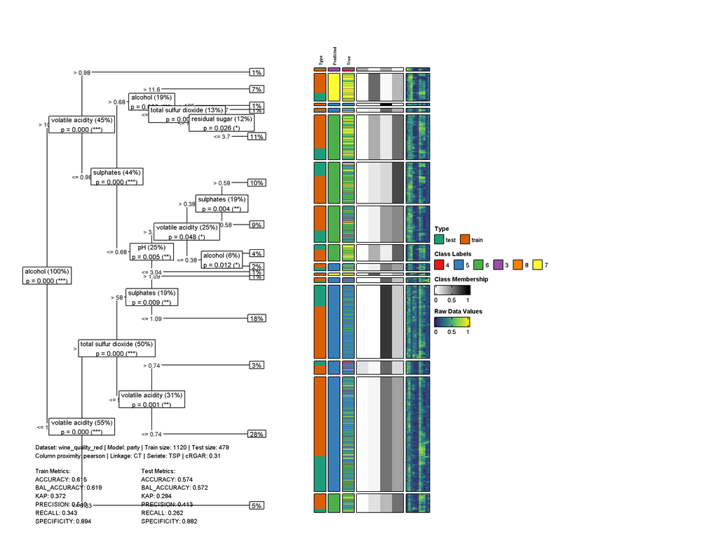

```r
dtGAP(
  data_all = wine_quality_red, target_lab = "target",
  show = "all", model = "party", simple_metrics = TRUE,
  tree_p = 0.4,
  show_col_prox = FALSE, show_row_prox = FALSE,
  y_eval_start = 40,
  raw_value_col = colorRampPalette(
    c("#33286b", "#26828e", "#75d054", "#fae51f")
  )(9),
  show_row_names = FALSE
)
```

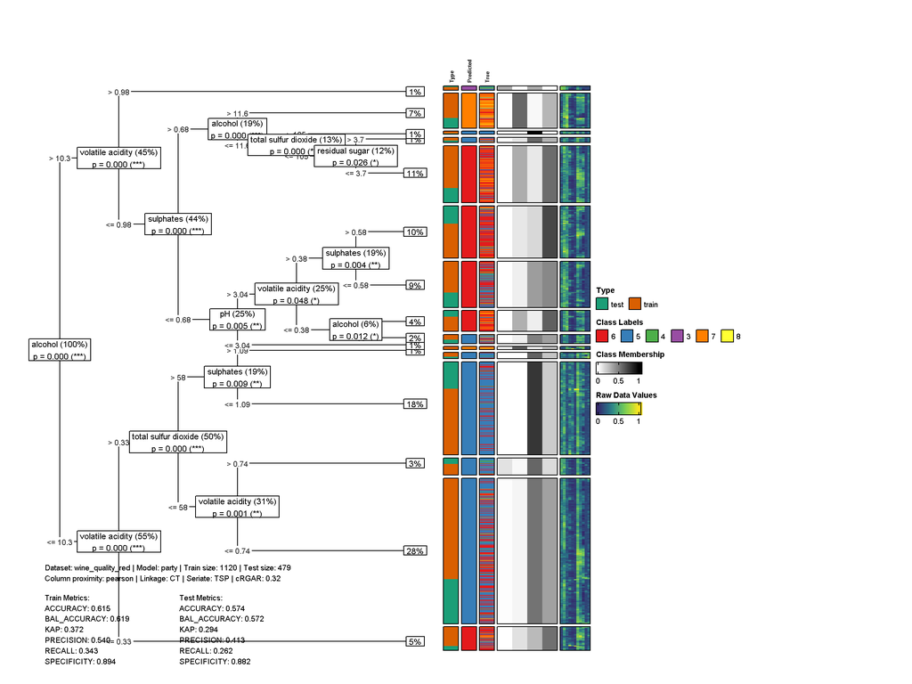

# 10 Variable Selection

Sometimes you may want to focus the heatmap on a subset of features while keeping the tree trained on all variables. The `select_vars` parameter lets you specify which variables to display—the tree still uses every feature for splitting, but only the selected ones appear in the heatmap panels.

```r
dtGAP(
  data_train = train_covid, data_test = test_covid,
  target_lab = "Outcome", show = "test",
  select_vars = c("LDH", "Lymphocyte"),
  label_map = c("0" = "Survival", "1" = "Death"),
  label_map_colors = c("Survival" = "#50046d", "Death" = "#fcc47f"),
  simple_metrics = TRUE,
  show_col_prox = FALSE, show_row_prox = FALSE,
  y_eval_start = 200,
  raw_value_col = colorRampPalette(
    c("#33286b", "#26828e", "#75d054", "#fae51f")
  )(9)
)
```

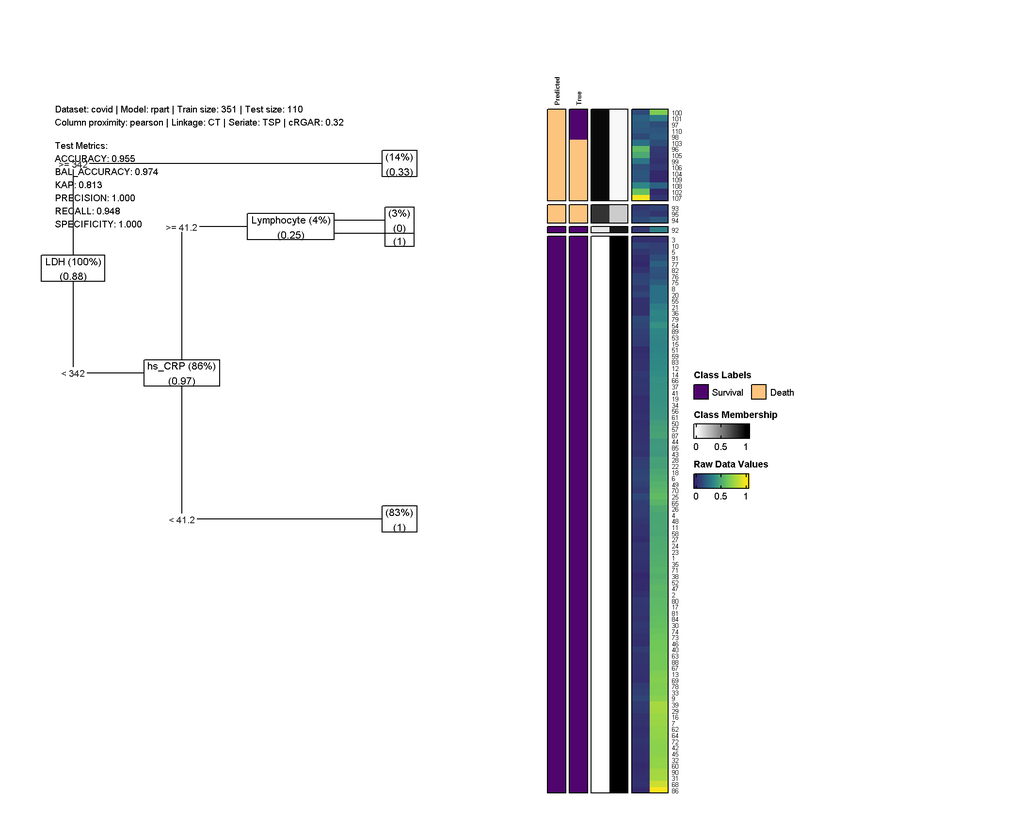

Note that `select_vars` must be a character vector of column names that exist in the data (excluding the target). Variable importance values are rescaled to sum to 1 for the selected subset.

# 11 Custom Tree Input

If you have already trained a decision tree outside of `dtGAP`, you can pass it directly using the `fit` parameter. This is useful when you want to use a specific tree configuration or compare a custom model with the built-in options.

`dtGAP()` accepts `rpart`, `party`, and `train` (caret) objects. The model type is automatically detected, and the tree is converted internally. You can optionally supply your own variable importance vector via `user_var_imp`.

```r
library(rpart)

# Train a custom rpart tree with specific parameters
custom_tree <- rpart(
  Outcome ~ ., data = train_covid,
  control = rpart.control(maxdepth = 3, cp = 0.01)
)

dtGAP(
  fit = custom_tree,
  data_train = train_covid, data_test = test_covid,
  target_lab = "Outcome", show = "test",
  label_map = c("0" = "Survival", "1" = "Death"),
  label_map_colors = c("Survival" = "#50046d", "Death" = "#fcc47f"),
  simple_metrics = TRUE,
  show_col_prox = FALSE, show_row_prox = FALSE,
  y_eval_start = 200,
  raw_value_col = colorRampPalette(
    c("#33286b", "#26828e", "#75d054", "#fae51f")
  )(9)
)
```

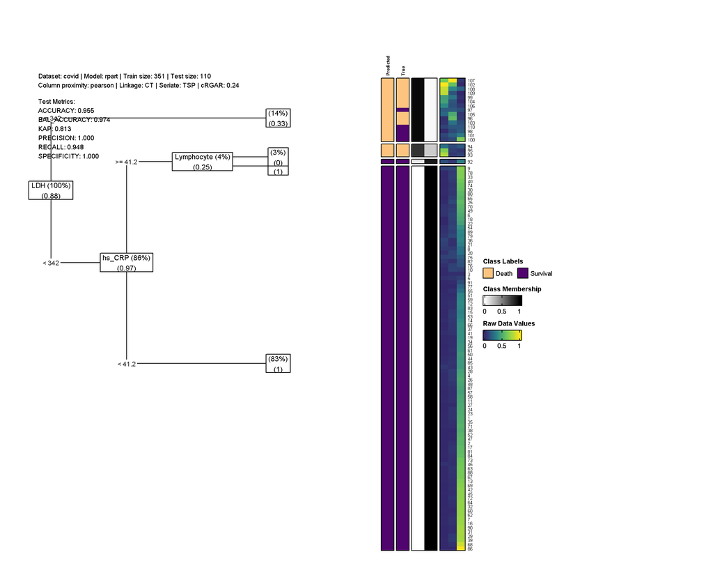

# 12 Interactive Visualization

Set `interactive = TRUE` to launch a Shiny-based interactive heatmap viewer powered by [InteractiveComplexHeatmap](https://bioconductor.org/packages/InteractiveComplexHeatmap/). This lets you hover, click, and zoom into the heatmap panels directly in your browser.

```r
dtGAP(
  data_train = train_covid, data_test = test_covid,
  target_lab = "Outcome", show = "test",
  interactive = TRUE, print_eval = FALSE
)
```

Note: `InteractiveComplexHeatmap` must be installed separately from Bioconductor:

```r
BiocManager::install("InteractiveComplexHeatmap")
```

In interactive mode, only the heatmap panels are displayed (the tree panel is omitted, as `InteractiveComplexHeatmap` handles ComplexHeatmap objects).

# 13 Multi-Model Comparison

The `compare_dtGAP()` function lets you compare two or more tree models side-by-side on a single wide canvas. Each model gets its own tree + heatmap panel with a label header.

```r
compare_dtGAP(
  models = c("rpart", "party"),
  data_train = train_covid, data_test = test_covid,
  target_lab = "Outcome", show = "test",
  label_map = c("0" = "Survival", "1" = "Death"),
  label_map_colors = c("Survival" = "#50046d", "Death" = "#fcc47f"),
  simple_metrics = TRUE,
  show_col_prox = FALSE, show_row_prox = FALSE,
  y_eval_start = 200,
  raw_value_col = colorRampPalette(
    c("#33286b", "#26828e", "#75d054", "#fae51f")
  )(9)
)
```

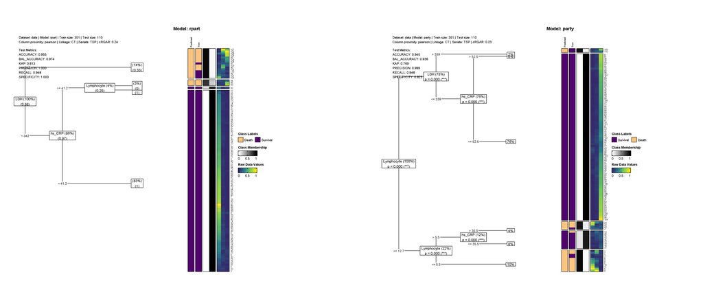

Supported models include `"rpart"`, `"party"`, `"C50"`, and `"caret"`. The default page width is 594 mm (two A4 pages side-by-side); you can adjust it with `total_w`.

# 14 Random Forest Extension

dtGAP extends beyond single decision trees with three functions for conditional random forests via `partykit::cforest`:

- `train_rf()` — train a conditional random forest
- `rf_summary()` — ensemble-level summary (variable importance + representative tree)
- `rf_dtGAP()` — visualize any individual tree from the forest using the full dtGAP pipeline

## 14.1 Training a Random Forest

`train_rf()` fits a `cforest` and returns the forest object, normalized variable importance, and the number of trees.

```r
rf <- train_rf(
  data_train = train_covid,
  target_lab = "Outcome",
  ntree = 50
)
names(rf)
```

```
#> [1] "forest"  "var_imp" "ntree"
```

```r
rf$var_imp
```

```
#>        LDH     hs_CRP Lymphocyte
#>        0.5        0.3        0.2
```

## 14.2 Ensemble Summary

`rf_summary()` provides an overview of the fitted random forest. It displays a variable importance barplot and identifies the **representative tree**—the individual tree whose predictions agree most closely with the full ensemble.

```r
result <- rf_summary(
  data_train = train_covid,
  data_test = test_covid,
  target_lab = "Outcome",
  ntree = 50,
  top_n_vars = 3
)
```

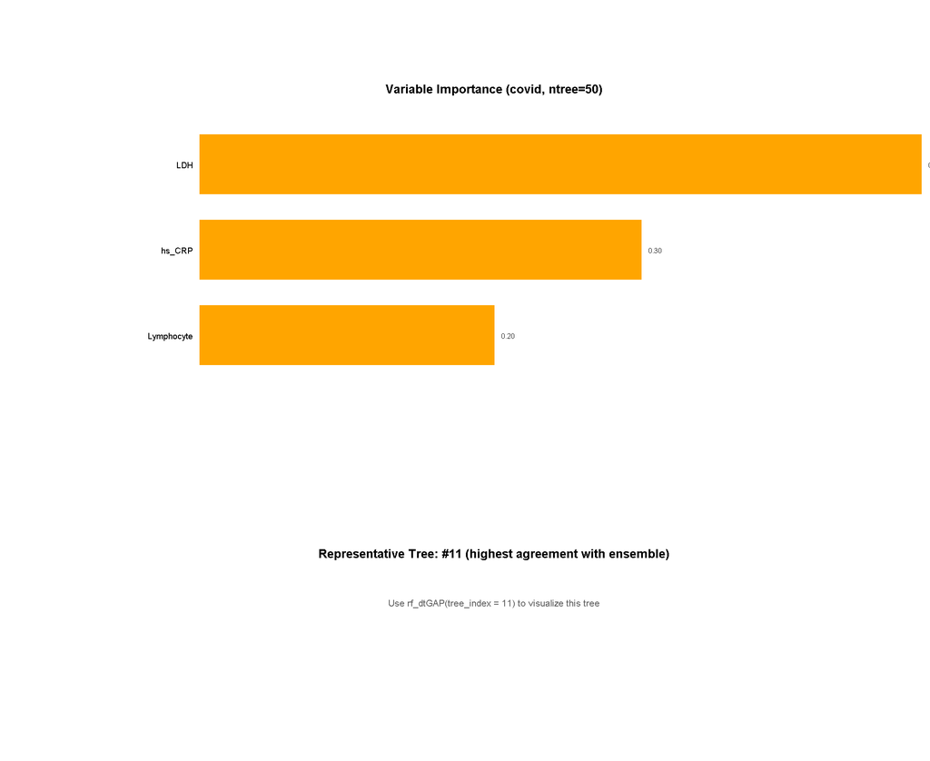

```r
result$rep_tree_index
```

```
#> [1] 11
```

The returned `rep_tree_index` tells you which tree best represents the ensemble, which you can then visualize with `rf_dtGAP()`.

## 14.3 Visualizing Individual Trees

`rf_dtGAP()` extracts a single tree from the forest and renders it through the full dtGAP pipeline (decision tree + heatmap + evaluation). The title automatically shows “Tree k/N”.

```r
rf_dtGAP(
  data_train = train_covid, data_test = test_covid,
  target_lab = "Outcome", show = "test",
  tree_index = 1, ntree = 50,
  label_map = c("0" = "Survival", "1" = "Death"),
  label_map_colors = c("Survival" = "#50046d", "Death" = "#fcc47f"),
  simple_metrics = TRUE,
  show_col_prox = FALSE, show_row_prox = FALSE,
  y_eval_start = 200,
  raw_value_col = colorRampPalette(
    c("#33286b", "#26828e", "#75d054", "#fae51f")
  )(9)
)
```

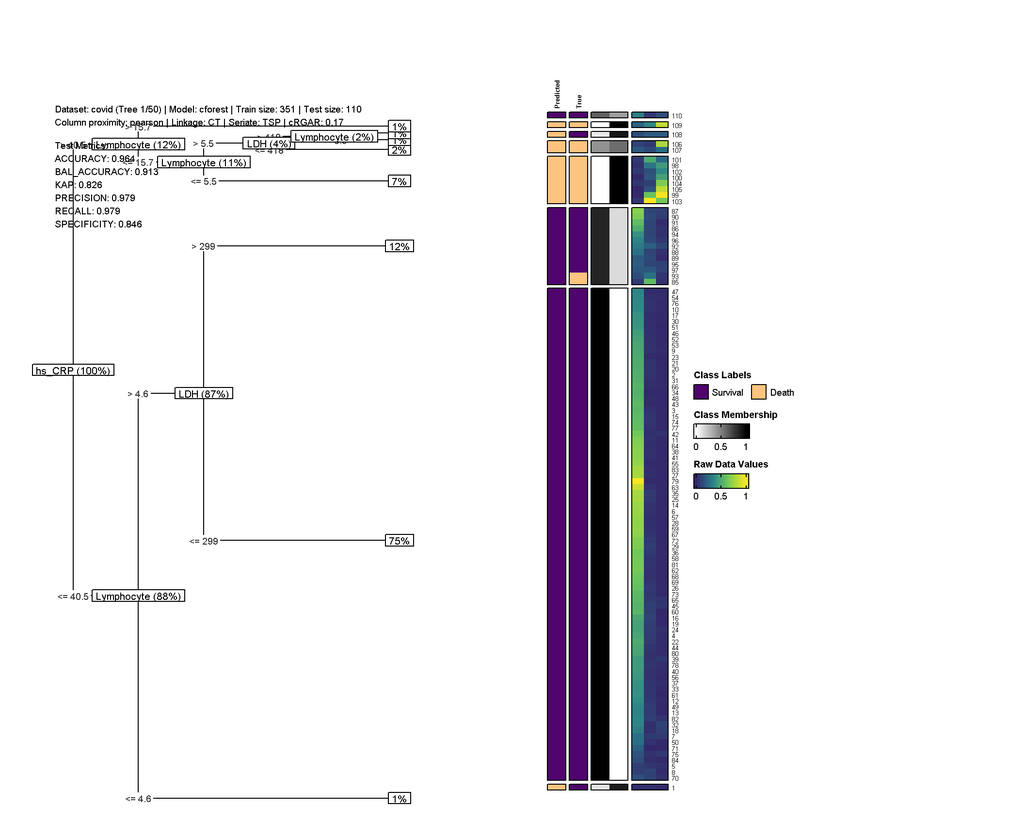

# 15 Exporting Plots

`save_dtGAP()` exports the dtGAP visualization to PNG, PDF, or SVG files. The format is automatically inferred from the file extension, or you can set it explicitly. Dimensions are specified in millimeters (default A4 landscape: 297 x 210 mm).

```r
# Save as PNG (300 dpi)
save_dtGAP(
  file = "my_plot.png",
  data_train = train_covid, data_test = test_covid,
  target_lab = "Outcome", show = "test",
  print_eval = FALSE
)

# Save as PDF
save_dtGAP(
  file = "my_plot.pdf",
  data_train = train_covid, data_test = test_covid,
  target_lab = "Outcome", show = "test",
  print_eval = FALSE
)

# Custom dimensions (wide format)
save_dtGAP(
  file = "wide_plot.svg",
  width = 500, height = 250,
  data_train = train_covid, data_test = test_covid,
  target_lab = "Outcome", show = "test",
  print_eval = FALSE
)
```

All `dtGAP()` arguments can be passed through `...`, so you can customize colors, metrics, and layout just as you would with `dtGAP()` directly.

# 16 Citation

Han-Ming Wu, Chia-Yu Chang, and Chun-houh Chen (2025), dtGAP: Supervised matrix visualization for decision trees based on the GAP framework. R package version 0.0.2, (https://github.com/hanmingwu1103/dtGAP).

**References:**

- Chen, C. H. (2002). Generalized association plots: Information visualization via iteratively generated correlation matrices. Statistica Sinica, 12, 7-29.
- Le, T. T., & Moore, J. H. (2021). Treeheatr: An R package for interpretable decision tree visualizations. Bioinformatics, 37(2), 282-284.
- Wu, H. M., Tien, Y. J., & Chen, C. H. (2010). GAP: A graphical environment for matrix visualization and cluster analysis. Computational Statistics & Data Analysis, 54(3), 767-778.